# Homework 7 - Normal Error Regression

Author

Brady Lamson

Published

April 9, 2025

All the questions below require you to use R and/or Stan to approximate the posterior distribution(s) of interest. I assume that you will do things like run multiple chains, calculate the Gelman-Rubin statistic, check the ACF of draws from the MCMC chain, determine the effective sample size, etc. However, I will only be looking at the posterior results. I recommend a warmup of 50,000 iterations and 50,000 saved values for each parameter using 4 chains. When presenting your posterior results, use a tabular format similar to below.

| Statistic | Mean | SD | 0.025 | 0.975 |
| --- | --- | --- | --- | --- |
| $\beta_0$ |  |  |  |  |
| $\beta_1$ |  |  |  |  |
| $\beta_2$ |  |  |  |  |
| $\beta_3$ |  |  |  |  |
| $\beta_4$ |  |  |  |  |
| $\sigma^2$ |  |  |  |  |

# Bank data

Ramsey and Schafer (2013) provide data related to bank employee salary for entry-level clerical employees hired by the Harris Trust and Savings Bank between 1969 and 1977. Let the response variable be beginning salary (`bsalary`) in thousands of dollars. Along with the intercept, there are four covariates:

- `male`: an indicator variable for whether the employee is male.
- `education`: years of education
- `experience`: months of experience
- `time`: time at hiring as measured in months after January 1, 1969.

The data are available in `bank_salary` data set in the **bayesutils** package available at https://github.com/jfrench/bayesutils.

Fit a multiple linear regression model using all four explanatory variables and the typical normal error regression model.

Assume that $\mathrm{Salary}_i \stackrel{indep.}{\sim} N(\mu_i, \sigma^2)$, where $\mu_i = \beta_0 + \beta_1 \mathrm{male}_i + \beta_2 \mathrm{education}_i + \beta_3 \mathrm{experience}_i + \beta_4 \mathrm{time}_i$, $i=1,2,\ldots,n$.

Use a Gamma(.01, .01) prior distribution for the precision $\tau$ (or an Inv-Gamma(0.01, 0.01) prior distribution for the data variance $\sigma^2$). We will change the priors for $\boldsymbol{\beta}$ in three different models below.

# Data Ingestion

```r
df <- bayesutils::bank_salary
```

# Problem 1

Model 1: Use independent normal priors for the regression coefficients, with mean 0 and variance $100^2$.

Provide the code used to fit your model.

**Solution**

**Stan model**

```r
stanmod = "
data {
  int<lower=1> n; // number of observations
  vector[n] y; // data
  vector[n] male; //covariate
  vector[n] edu; //covariate
  vector[n] exp; //covariate
  vector[n] time; //covariate
  real<lower=0> v; // sample variance of y
}
parameters {
  real<lower=0> prec; // tau
  real beta0;
  real beta1;
  real beta2;
  real beta3;
  real beta4;
}
transformed parameters{
  real<lower=0> sigma; //get sigma from the precision
  sigma = sqrt(1/prec);
}
model {
  //specify priors
  beta0 ~ normal(0.0, 100);
  beta1 ~ normal(0.0, 100);
  beta2 ~ normal(0.0, 100);
  beta3 ~ normal(0.0, 100);
  beta4 ~ normal(0.0, 100);
  prec ~ gamma(0.01, 0.01);

  // data distribution
  for(i in 1:n){
    y[i] ~ normal(beta0 + beta1*male[i] + beta2*edu[i] + beta3*exp[i] + beta4*time[i], sigma);
  }
}
generated quantities {
  real<lower=0> sigmasq; //get sigmasq from the precision
  real Rbsq;
  sigmasq = 1/prec;
  Rbsq = 1 - sigmasq / v;
}
"
```

**Running the model**

```r
n <- nrow(df)
v <- var(df$bsalary)

stan_dat <- list(n=n, y=df$bsalary, male=df$male, edu=df$education, exp=df$experience, time=df$time, v=v)

# if compiled model doesn't already exist,
# compile the model, sample from model,
# returns object of class stan
# save model
if (!file.exists("bank_mod1.rda")) {
  # compile and sample from model
  bank_fit = stan(model_code = stanmod,
                             data = stan_dat,
                             iter = 100000,
                             chains = 4)
  # alternatively, describe model
  bank_mod = stan_model(model_code = stanmod)
  save(bank_mod,
       file = "bank_mod1.rda",
       compress = "xz")
} else {
    load(file = "bank_mod1.rda")
    # draw samples from the model
    bank_fit = sampling(
        bank_mod,
        data = stan_dat,
        iter = 100000,
        chains = 4
    )
}
```

# Problem 2

Provide the posterior mean, standard deviation, 0.025, and 0.975 quantiles for all regression coefficients and the variance $\sigma^2$ in a simple tabular format.

**Solution**

| Statistic | Mean | SD | 0.025 | 0.975 |
| --- | --- | --- | --- | --- |
| $\beta_0$ | 3.52543947 | 0.33117008 | 2.87466044 | 4.17709164 |
| $\beta_1$ | 0.72232391 | 0.11958235 | 0.48732577 | 0.95696108 |
| $\beta_2$ | 0.09007136 | 0.02493631 | 0.04081261 | 0.13896373 |
| $\beta_3$ | 0.00126836 | 0.00059607 | 0.00009726 | 0.00244207 |
| $\beta_4$ | 0.02344778 | 0.00528185 | 0.01303559 | 0.03381004 |
| $\sigma^2$ | 0.26369900 | 0.04070257 | 0.19559452 | 0.35501293 |

# Problem 3

Provide the code used to fit a model using a general Zellner’s g-prior.

**Solution**

**Stan model**

```r
stanmod = "
data {
  int<lower=1> n; // number of observations
  vector[n] y; // data
  matrix[n, 5] X; //covariates
  vector[5] mu0; //prior mean for beta
  cov_matrix[5] V; //V part of Zellner's g-prior
  cov_matrix[n] I; //nxn identity matrix
  real<lower=0> csq; //constant for Zellner's g-prior
  real<lower=0> v; //sample variance
}
parameters {
  real<lower=0> prec;
  vector[5] beta;
}
transformed parameters{
  real<lower=0> sigmasq; //get sigmasq from the precision
  vector[n] mu;  // mean of responses
  sigmasq = 1/prec;
  mu = X * beta;
}
model {
  // specify priors
  beta ~ multi_normal(mu0, sigmasq*csq*V);
  prec ~ gamma(0.01, 0.01);

  // specify data distribution
  // y ~ multi_normal(mu, sigmasq * I);
  // The statement below is equivalent to what is above,
  // but faster since we don't sample from a multivariate
  // normal distribution internally.
  for(i in 1:n) {
    y[i] ~ normal(mu[i], sqrt(sigmasq));
  }
}
generated quantities {
  real Rbsq;
  Rbsq = 1 - sigmasq / v;
}
"
```

**Running the model**

```r
n <- nrow(df)
v <- var(df$bsalary)
X <- cbind(1, df$male, df$education, df$experience, df$time)

stan_dat = list(
    n = n,
    y = df$bsalary,
    X = X,
    mu0 = rep(0, 5),
    V = solve(crossprod(X)),
    I = diag(n),
    csq = n, v = v
)

# if compiled model doesn't already exist,
# compile the model, sample from model,
# returns object of class stan
# save model
if (!file.exists("bank_mod2.rda")) {
  print("Compiling Model")
  # compile and sample from model
  bank_fit2 = stan(model_code = stanmod,
                             data = stan_dat,
                             iter = 100000,
                             chains = 4)
  # alternatively, describe model
  bank_mod2 = stan_model(model_code = stanmod)
  save(bank_mod2,
       file = "bank_mod2.rda",
       compress = "xz")
} else {
    print("Loading pre-compiled model")
    load(file = "bank_mod2.rda")
    # draw samples from the model
    bank_fit2 = sampling(
        bank_mod2,
        data = stan_dat,
        iter = 100000,
        chains = 4
    )
}
```

# Problem 4

Model 2: Use the default Zellner’s g-prior $\boldsymbol{\beta}$ ($c^2=n$) to fit the corresponding regression model.

Provide the posterior mean, standard deviation, 0.025, and 0.975 quantiles for all regression coefficients and the variance $\sigma^2$ in a simple tabular format.

**Solution**

| Statistic | Mean | SD | 0.025 | 0.975 |
| --- | --- | --- | --- | --- |
| $\beta_0$ | 3.49090280 | 0.48593480 | 2.53520700 | 4.43977668 |
| $\beta_1$ | 0.71523089 | 0.17457346 | 0.37318798 | 1.05838822 |
| $\beta_2$ | 0.08889521 | 0.03663930 | 0.01709412 | 0.16115403 |
| $\beta_3$ | 0.00125346 | 0.00087093 | -0.00045951 | 0.00295790 |
| $\beta_4$ | 0.02316593 | 0.00769559 | 0.00810912 | 0.03835335 |
| $\sigma^2$ | 0.57087102 | 0.08538284 | 0.42734418 | 0.76189782 |

# Problem 5

Model 3: Use a conservative Zellner’s g-prior for $\boldsymbol{\beta}$ with $c^2=1000$.

Provide the posterior mean, standard deviation, 0.025, and 0.975 quantiles for all regression coefficients and the variance $\sigma^2$ in a simple tabular format.

**Solution**

**Running the model**

```r
stan_dat = list(
    n = n,
    y = df$bsalary,
    X = X,
    mu0 = rep(0, 5),
    V = solve(crossprod(X)),
    I = diag(n),
    csq = 1000,
    v = v
)

# if compiled model doesn't already exist,
# compile the model, sample from model,
# returns object of class stan
# save model
if (!file.exists("bank_mod3.rda")) {
  print("Compiling Model")
  # compile and sample from model
  bank_fit3 = stan(model_code = stanmod,
                             data = stan_dat,
                             iter = 100000,
                             chains = 4)
  # alternatively, describe model
  bank_mod3 = stan_model(model_code = stanmod)
  save(bank_mod3,
       file = "bank_mod3.rda",
       compress = "xz")
} else {
    print("Loading pre-compiled model")
    load(file = "bank_mod3.rda")
    # draw samples from the model
    bank_fit3 = sampling(
        bank_mod3,
        data = stan_dat,
        iter = 100000,
        chains = 4
    )
}
```

| Statistic | Mean | SD | 0.025 | 0.975 |
| --- | --- | --- | --- | --- |
| $\beta_0$ | 3.52439503 | 0.34071766 | 2.85408233 | 4.19248122 |
| $\beta_1$ | 0.72191150 | 0.12211989 | 0.48235411 | 0.96165738 |
| $\beta_2$ | 0.08980052 | 0.02562253 | 0.03964671 | 0.14005102 |
| $\beta_3$ | 0.00126518 | 0.00061152 | 0.00006657 | 0.00246328 |
| $\beta_4$ | 0.02339360 | 0.00539434 | 0.01278765 | 0.03399622 |
| $\sigma^2$ | 0.27931385 | 0.04180661 | 0.20916396 | 0.37239053 |

# Problem 6

Compare the posterior distributions for $R_b^2$ for all three models (with proper labeling) in a single plot. Which model appears to have the best fit?

**Solution**

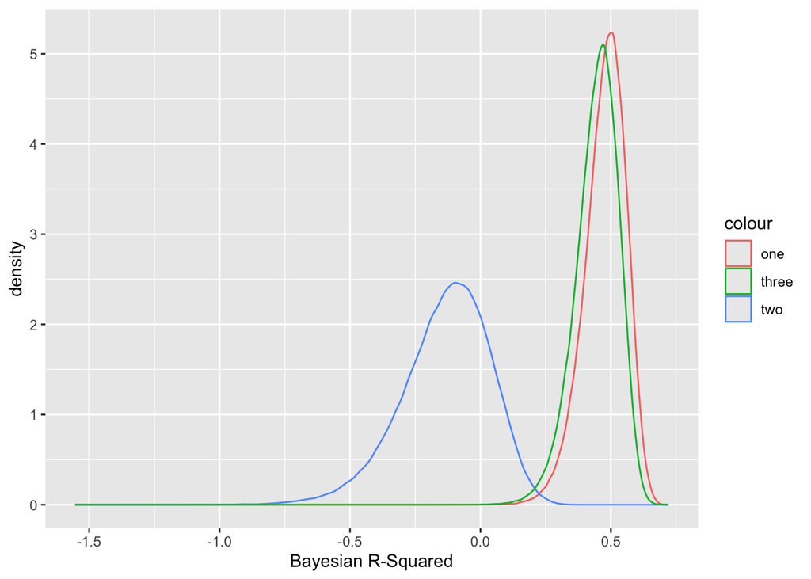

```r
rbsq1 <- rstan::extract(bank_fit, pars = "Rbsq")$Rbsq
rbsq2 <- rstan::extract(bank_fit2, pars = "Rbsq")$Rbsq
rbsq3 <- rstan::extract(bank_fit3, pars = "Rbsq")$Rbsq

ggplot() +
    geom_density(aes(x=rbsq1, color = "one")) +
    geom_density(aes(x=rbsq2, color = "two")) +
    geom_density(aes(x=rbsq3, color = "three")) +
    xlab(label = "Bayesian R-Squared")
```

None of these models seem particularly great. Models one and three are similar with model one eeking out a little further ahead in performance. Model 2 is a strange one. I want to talk about it a bit.

So we have what is primarily a negative $R_b^2$. It’s also very wide. Why? If we refer back to model 2’s aggregate result for its’ estimate of $\sigma^2$ we get $0.571$ with the widest of the three intervals from the models. If we look the sample variance from our data we have $S^2 = 0.503$ which is smaller than our estimate. That’s the problem.

```
generated quantities {
  real Rbsq;
  Rbsq = 1 - sigmasq / v;
}
```

$R_b^2$ is negative here because of that. As for why this models estimate is so much larger than the others? It must be due to the default value of Zellner’s g-prior giving too much weight to the data. Model 3 is nearly identical but just uses a more conservative g-prior and doesn’t show the same behavior.

# Problem 7

Provide a point estimate (using the posterior means) of the regression equation for Model 1. Interpret $\beta_{0}$, $\beta_{2}$ for Model 1 in the context of the problem.

**Solution**

We have:

$$\hat{y} = 3.53 + 0.72X_1 + 0.09X_2 + 0.001X_3 + 0.02X_4 + \epsilon$$

$\beta_0$ interpretation: The expected salary a posteriori of a newly hired, non-male with 0 years of education and 0 years of experience is $3.53$ $[2.87, 4.18]$ thousand dollars.

$\beta_2$ interpretation: The expected salary a posteriori increases by about $0.09$ $[0.04, 0.14]$ thousand dollars for every additional year of education assuming the same gender, years of experience, and time since being hired.